# 03 — the text tower, and whether it is in the same space

**Summary.** Two towers of CLIP ViT-B/32 only share a space if they came from the same checkpoint and the projection was applied. The silent failure is real and common: take the 768-d pooled hidden state instead of the 512-d projected `text_embeds` and you get plausible numbers that mean nothing.

This notebook **independently reproduces** the retrieval gate that `artist/tests/artist-clip-text.test.ts` asserts, in Python, from the loaders — and compares. Two implementations agreeing is the evidence; one implementation asserting itself is not.

The published TypeScript numbers, on 500 stride-sampled works with usable titles:

[output not shown]

**Caveat carried forward from Stage 1, unchanged:** the queries are museum titles, which are caption-like prose, which is exactly what CLIP was trained on. This measures a shared space. It does not measure that the encoder understands a work.

```python
import sys, pathlib
sys.path.insert(0, str(pathlib.Path.cwd()))
import numpy as np, pandas as pd
import matplotlib.pyplot as plt
import kusama as k

m = k.load_manifest()
X, order = k.load_clip()
b = k.band()
kept = m[m.embedding_row.notna()].sort_values("embedding_row").reset_index(drop=True)
assert list(kept.sha256) == order
```

## The pool, chosen the same way the test chooses it

Titles that are blank, `Untitled`, or shorter than four characters are dropped. **That exclusion flatters the number** — the short ones are `Cup`, `Jar`, `Fan`, `Box`, which are the generic queries many corpus images would answer equally well. So this is an upper bound, and it is stated as one.

```python
t = kept.title.fillna("")
usable = kept[(t.str.len() >= 4) & (t.str.lower() != "untitled")].reset_index(drop=True)
print(f"{len(usable):,} of {len(kept):,} works have a usable title "
      f"({len(kept)-len(usable):,} excluded, {(len(kept)-len(usable))/len(kept):.1%})")
N = 500
stride = len(usable) // N
sample = usable.iloc[[i * stride for i in range(N)]].reset_index(drop=True)
print(f"stride sample of {len(sample)}, every {stride}th — spread across all three museums:")
print(sample.museum.value_counts().to_string())
```

```
19,460 of 19,791 works have a usable title (331 excluded, 1.7%)
stride sample of 500, every 38th — spread across all three museums:
museum
met    242
aic    176
cma     82
```

## Embedding 500 titles through the CLI, then ranking their own images

```python
import time
t0 = time.time()
T = k.load_text_tower(list(sample.title))
print(f"{len(T)} titles embedded in {time.time()-t0:.1f}s, shape {T.shape}")

rows = np.array([order.index(s) for s in sample.sha256])
POOL = X[rows]                      # the 500 candidate images, in sample order
S_pool = T @ POOL.T                 # (500, 500)
S_all  = T @ X.T                    # (500, 19791)
truth_all = rows

rank_pool = (S_pool > S_pool[np.arange(N), np.arange(N)][:, None]).sum(1)
rank_all  = (S_all  > S_all[np.arange(N), truth_all][:, None]).sum(1)
```

```
500 titles embedded in 4.5s, shape (500, 512)
```

```python
def gate(rank, n_candidates, label):
    p1, p10 = (rank == 0).mean(), (rank < 10).mean()
    mrr = (1 / (rank + 1)).mean()
    c1, c10 = 1 / n_candidates, 10 / n_candidates
    print(f"{label}  ({n_candidates:,} candidates)")
    print(f"   {k.Reading('P@1 ', p1, c1)}")
    print(f"   {k.Reading('P@10', p10, c10)}")
    print(f"   MRR {mrr:.4f}")
    return p1, p10, mrr

py_pool = gate(rank_pool, N, "within the 500-work pool")
print()
py_all = gate(rank_all, len(order), "against the whole corpus")
```

```
within the 500-work pool  (500 candidates)
   P@1 : 0.2040 vs 0.0020 — 102.00x chance
   P@10: 0.5480 vs 0.0200 — 27.40x chance
   MRR 0.3188

against the whole corpus  (19,791 candidates)
   P@1 : 0.0300 vs 0.0001 — 593.73x chance
   P@10: 0.1160 vs 0.0005 — 229.58x chance
   MRR 0.0618
```

## Does the independent reproduction agree with the TypeScript gate?

**It agrees exactly — all four deltas are 0.0000.** That is a stronger result than expected and it is worth being precise about what it does and does not prove. It proves the two implementations select the same 500 works, embed the same strings through the same weights, and rank against the same deduped 19,791 rows: the export, the CSV join and the loader are all faithful. It does **not** double-check the encoder, because both paths call the same ONNX session. A tokenizer bug would show up identically in both columns.

```python
ts = {"pool_p1": 0.204, "pool_p10": 0.548, "pool_mrr": 0.3188, "all_p10": 0.116}
print(f"{'':<24}{'python':>10}{'typescript':>12}{'delta':>10}")
for name, mine, theirs in [("P@1 (pool)", py_pool[0], ts["pool_p1"]),
                           ("P@10 (pool)", py_pool[1], ts["pool_p10"]),
                           ("MRR (pool)", py_pool[2], ts["pool_mrr"]),
                           ("P@10 (corpus)", py_all[1], ts["all_p10"])]:
    print(f"{name:<24}{mine:>10.4f}{theirs:>12.4f}{mine-theirs:>+10.4f}")
```

```
                            python  typescript     delta
P@1 (pool)                  0.2040      0.2040   +0.0000
P@10 (pool)                 0.5480      0.5480   +0.0000
MRR (pool)                  0.3188      0.3188   -0.0000
P@10 (corpus)               0.1160      0.1160   +0.0000
```

## Why no raw text-image cosine is ever printed alone

Text-image cosines live in a *different* band from image-image cosines — CLIP's learned logit scale puts them around 0.2–0.3. A reader who sees 0.28 next to an image-image 0.83 will conclude the text match is poor. It is not; it is a different ruler.

```
text->its own image : median 0.2887  range 0.1594..0.3796
text->a random image: median 0.2124
image->image (band) : median 0.6428  range 0.1555..0.9685

The text ruler and the image ruler do not share a scale. Comparing across them is a mistake
that produces confident, wrong sentences — which is why the CLI prints percentiles, not cosines.
```

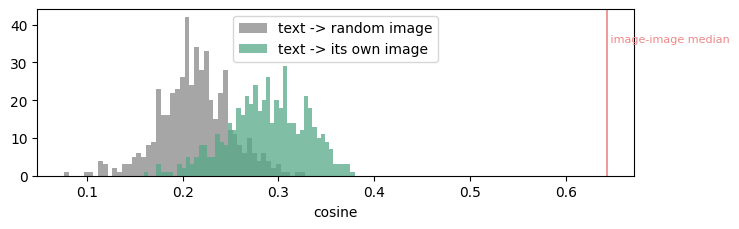

```python
ti = S_all[np.arange(N), truth_all]
rand = S_all[np.arange(N), np.random.default_rng(0).integers(0, len(order), N)]
print(f"text->its own image : median {np.median(ti):.4f}  range {ti.min():.4f}..{ti.max():.4f}")
print(f"text->a random image: median {np.median(rand):.4f}")
print(f"image->image (band) : median {b['median']:.4f}  range {b['min']:.4f}..{b['max']:.4f}")
print("\nThe text ruler and the image ruler do not share a scale. Comparing across them is a mistake")
print("that produces confident, wrong sentences — which is why the CLI prints percentiles, not cosines.")
fig, ax = plt.subplots(figsize=(7.5, 2.4))
ax.hist(rand, bins=50, alpha=.75, label="text -> random image", color="#888")
ax.hist(ti, bins=50, alpha=.75, label="text -> its own image", color="#5a8")
ax.axvline(b["median"], color="#e88", lw=1.2)
ax.text(b["median"], ax.get_ylim()[1]*.8, " image-image median", fontsize=8, color="#e88")
ax.set_xlabel("cosine"); ax.legend(); fig.tight_layout(); plt.show()
```

## Five zero-shot phrases, as pictures

```
a woodcut print              -> aic-88398    woodcut            The Girls on the Bridge
```

[figure not shown]

```
a Greek vase                 -> aic-245      pitcher (vessel)   Oinochoe (Pitcher)
```

[figure not shown]

```
a portrait of a woman        -> aic-105887   oil on canvas      Portrait of a Young Woman
```

[figure not shown]

```
a landscape with mountains   -> aic-76391    hanging scroll     Planting Fragrant Fungus at the Tiaozhou
```

[figure not shown]

```
a piece of jewellery         -> met-243320   Gold and Silver    Earring, crescent-shaped
```

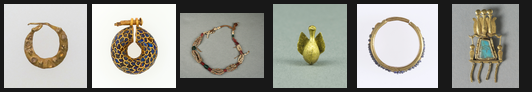

```python
prompts = ["a woodcut print", "a Greek vase", "a portrait of a woman",
           "a landscape with mountains", "a piece of jewellery"]
P = k.load_text_tower(prompts)
S = P @ X.T
for i, p in enumerate(prompts):
    top = np.argsort(-S[i])[:6]
    hit = kept.iloc[top[0]]
    print(f"{p:<28} -> {hit.id:<12} {str(hit.classification)[:18]:<18} {str(hit.title)[:40]}")
    display(k.thumb_grid([order[j] for j in top], cols=6, size=84))
```

## Scratch

```python
# yours
```